# Why Am I Hungry Again?

An Investigation Into My Eating Habits and Satiety

A personal reflection on food intake, fullness, exercise, and hunger patterns.  
This exploration became less about numbers over time, and more about noticing patterns in my own body: when I tend to get hungry, what kinds of meals actually sustain me, and how movement affects my sense of fullness.

## How often do i feel hungry during a day?

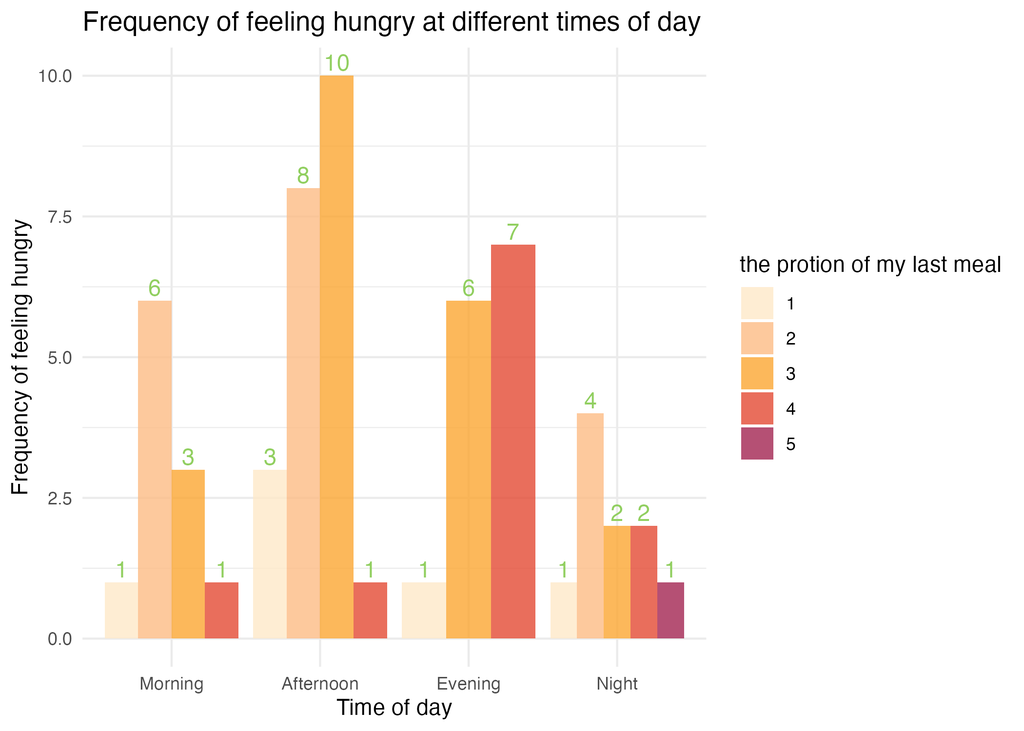

plot of frequency of hunger by time

This bar chart illustrates how often I experienced hunger during different times of the day.  
My hungery times were grouped into Morning, Afternoon, Evening, and Night categories to identify temporal patterns in hunger frequency.

The results suggest that my feelings of hunger are not evenly distributed throughout the day, and i tend to usually get hungry during the Afternoon. This pattern may be related to the relatively smaller portions of food I tend to consume earlier in the day, and it is true that I do sometimes have small portion breakfast during the morning.

## How long do different portion sizes keep me full?

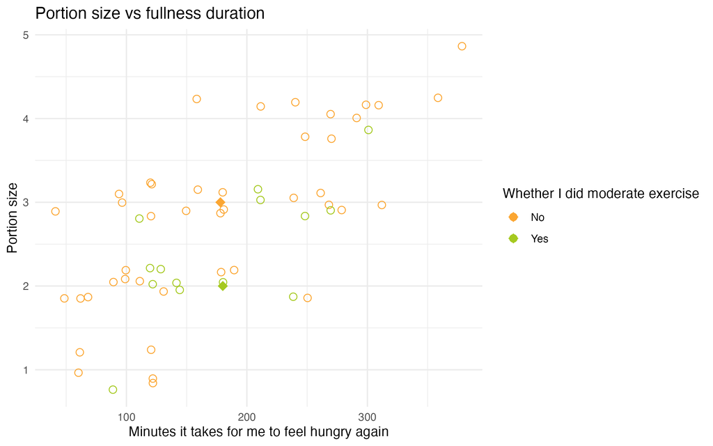

plot of portion size vs fullness duration

This scatter plot explores the relationship between the portion size of my previous meal and the amount of time it took before I felt hungry again. (With the diamond-shaped points indicate the average values for cases where I did or did not perform moderate exercise.)

The pattern indicates that larger meal portions generally tended to keep me full for longer periods of time, so portion size does play a strong role in sustaining satiety as expected.

In addition, the diamond points (averages) show an interesting contrast:

- When I did moderate exercise, I stayed full for an average of 180 minutes (3 hours)
- When I did not exercise, I stayed full for an average of 178 minutes (3 hours)

It is interesting as I expected exercise to make me hungrier sooner with more obvious difference but instead, when I engage in moderate physical activity, fullness duration actually tends to be even a bit longer compare to when I didn’t exercise. Which means that exercise may enhance differences depending on how much I previously ate — especially noticeable when meal portions are smaller, the outcomes are more varied across duration.

And another thing I found through the plot is that I might tend to usually have less portion than i thought, I should from now on increase in the portion of the meal I have to sustain my health and fullness for longer time.

## What types of food keep me full for longer?

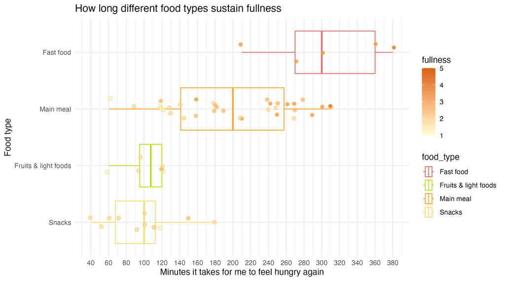

plot of food type vs duration of fullness

This box plot compares how long different categories of food sustained fullness before I felt hungry again.

The individual jittered points represent separate observations, while the boxplots summarise the overall distribution for each food category. Point colour intensity reflects my recorded fullness level after eating my last meal.

The results suggest that heavier meals such as main meals and fast food which come with more higher fullness level, generally tended to sustain fullness for longer periods compared with lighter foods and snacks. In contrast, fruits and lighter foods often corresponded with shorter duration before hunger returned.

Also seeing from the points, my dietary is meanly about main dishes, slight snacks with very few fruits and sometimes large amount of fast foods. Which is fairly healthy but I can increase more in consuming fruits and form a more healthy dietary.